# Tarea 8.2

Alex Llanes Quevedo

## Analisis de diversidad con datos de metagenomas de hongos

#### *1. Crear una tabla de OTU binomial (presencia/ausencia) usando la función decostand (method=“pa”) del paquete de vegan*

**No encontré la tabla de binary en el cluster y tampoco pude hacerla yo, por lo que realicé el tutorial con el archivo .biom que obtuve al correr AMTpk. Entiendo las diferencias de trabajar con los datos de número de OTU por muestra y número de reads de cada OTU presente en la muestra, pero creo que las instrucciones siguientes serían similares aun si el objeto mybiom fuera la tabla de presencia/ausencia**

#### *2. Realizar un plot_bar de la abundancia (de los reads) de OTUs por phylum en cada hospedero y tratamiento usando facet_wrap*

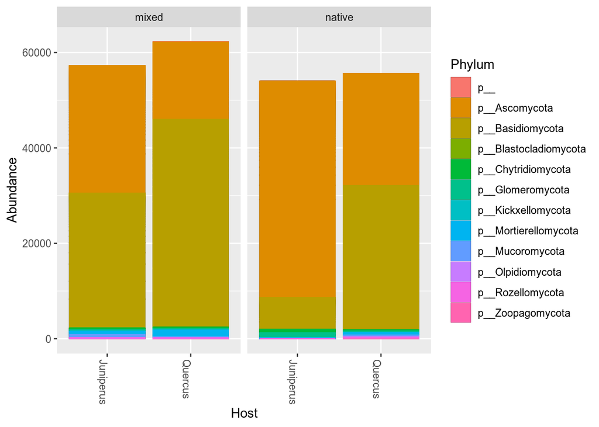

```r
p = plot_bar(mybiom, "Host", fill = "Phylum") + geom_bar(aes(color=Phylum, fill=Phylum),stat = "identity", position = "stack")
p + facet_wrap("Treatment")
```

#### *3. Calcular la riqueza observada*

```r
diversity = estimate_richness(mybiom, measures = "Observed")
data <- cbind(sample_data(mybiom), diversity)
diversity
```

```
##                   Observed
## A1.JM2.2.2621739        80
## A12.QM1.2.2621927      318
## B12.QM2.2.2621928      322
## E3.JN1.2.2621809        90
## F2.QN3.2.2621802       109
## F3.JN2.2.2621810        61
## F9.QM3.2.2621908       212
## G2.QN1.2.2621803        98
## G3.JM1.2.2621811        76
## H2.JM3.2.2621804       176
## H11.JN3.2.2621926      374
## H12.QN2.2.2621934      343
```

#### *4. Hacer un ANOVA de la riqueza observada (“Observed”) por hospedero y tratamiento (two-way)*

```r
host.treat <- aov(Observed ~ Host * Treatment, data = data)
summary(host.treat)
```

```
##                Df Sum Sq Mean Sq F value Pr(>F)
## Host            1  24752   24752   1.763  0.221
## Treatment       1    990     990   0.071  0.797
## Host:Treatment  1  20419   20419   1.454  0.262
## Residuals       8 112317   14040
```

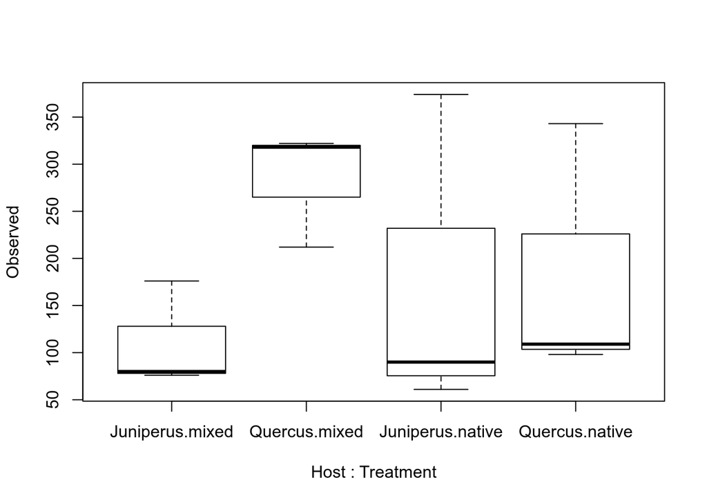

```r
boxplot(Observed ~ Host * Treatment, data = data)
```

```r
raup_dist <- distance(mybiom, method = "raup")
NMDS<-ordinate(mybiom, method = "NMDS", color = "Host", shape = "Treatment")
```

```
## Square root transformation
## Wisconsin double standardization
## *** Solution reached
```

```r
NMDS
```

```
##
## Call:
## metaMDS(comm = veganifyOTU(physeq), distance = distance, color = "Host",      shape = "Treatment")
##
## global Multidimensional Scaling using monoMDS
##
## Data:     wisconsin(sqrt(veganifyOTU(physeq)))
## Distance: bray
##
## Dimensions: 2
## Stress:     0.1232448
## Stress type 1, weak ties
## Two convergent solutions found after 20 tries
## Scaling: centring, PC rotation
## Species: expanded scores based on 'wisconsin(sqrt(veganifyOTU(physeq)))'
```

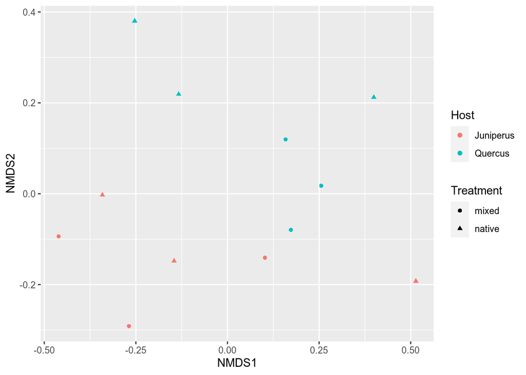

```r
plot_ordination(mybiom, NMDS, color = "Host", shape = "Treatment")
```

#### *6. Hacer un Test de adonis de la composición de la comunidad por hospedero y tratamiento*

```r
adonis(raup_dist ~ Host * Treatment, data = data)
```

```
##
## Call:
## adonis(formula = raup_dist ~ Host * Treatment, data = data)
##
## Permutation: free
## Number of permutations: 999
##
## Terms added sequentially (first to last)
##
##                Df SumsOfSqs  MeanSqs F.Model      R2 Pr(>F)
## Host            1   0.23671 0.236705  5.2258 0.22812  0.030 *
## Treatment       1   0.27707 0.277068  6.1169 0.26702  0.019 *
## Host:Treatment  1   0.16148 0.161478  3.5650 0.15562  0.083 .
## Residuals       8   0.36236 0.045295         0.34923
## Total          11   1.03761                  1.00000
## ---
## Signif. codes:  0 '***' 0.001 '**' 0.01 '*' 0.05 '.' 0.1 ' ' 1
```

#### Nota: Realmente no conozco mucho sobre el Test adonis, y lo que he leído para generar este reporte (teoría, diferencias con los ANOVAs, dudas en algunos foros de bioinformática) no me ha traído mucha más claridad al respecto, lo que limita la discusión que pueda realizar del planteamiento anteriormente expuesto.